# MPDW Kuliah IPM

Ibrahim Zaidan

2025-08-29

# Download Package dan Eksplorasi Data

```r
library(readxl); library(dplyr)

data_path <- "C:/Users/De Ibrahim/kuliah/sem 5/Kuliah/Data IPM Kab Bekasi.xlsx"

df <- read_excel(data_path)

names(df) <- gsub("\\s+","", names(df))

if(!"Tahun" %in% names(df)) stop("Kolom 'Tahun' tidak ditemukan.")
ipm_col <- setdiff(names(df)[sapply(df, is.numeric)], "Tahun")
if(length(ipm_col) != 1) stop("Harus ada tepat satu kolom IPM numerik.")
ipm_name <- ipm_col

dat <- df %>%
  select(Tahun, IPM = all_of(ipm_name)) %>%
  arrange(Tahun)

print(dat)
```

```
## # A tibble: 15 × 2
##    Tahun   IPM
##    <dbl> <dbl>
##  1  2010  67.6
##  2  2011  68.7
##  3  2012  69.4
##  4  2013  70.1
##  5  2014  70.5
##  6  2015  71.2
##  7  2016  71.8
##  8  2017  72.6
##  9  2018  73.5
## 10  2019  74.0
## 11  2020  74.5
## 12  2021  74.8
## 13  2022  75.6
## 14  2023  76.1
## 15  2024  76.8
```

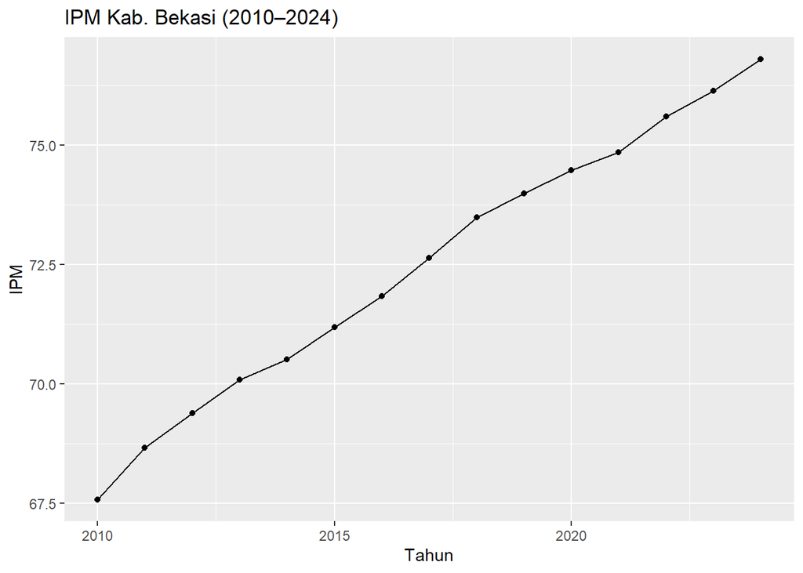

```r
library(ggplot2)
ggplot(dat, aes(x = Tahun, y = IPM)) +
  geom_line() +
  geom_point() +
  labs(title = "IPM Kab. Bekasi (2010–2024)", x = "Tahun", y = "IPM")
```

Time-Series plot di atas menunjukkan seiring waktu, IPM semakin naik

```r
mod <- lm(IPM ~ Tahun, data = dat)
summary(mod)
```

```
##
## Call:
## lm(formula = IPM ~ Tahun, data = dat)
##
## Residuals:
##      Min       1Q   Median       3Q      Max
## -0.43433 -0.10648 -0.01148  0.12031  0.37281
##
## Coefficients:
##               Estimate Std. Error t value Pr(>|t|)
## (Intercept) -1.214e+03  2.462e+01  -49.31 3.59e-16 ***
## Tahun        6.379e-01  1.221e-02   52.25  < 2e-16 ***
## ---
## Signif. codes:  0 '***' 0.001 '**' 0.01 '*' 0.05 '.' 0.1 ' ' 1
##
## Residual standard error: 0.2043 on 13 degrees of freedom
## Multiple R-squared:  0.9953, Adjusted R-squared:  0.9949
## F-statistic:  2730 on 1 and 13 DF,  p-value: < 2.2e-16
```

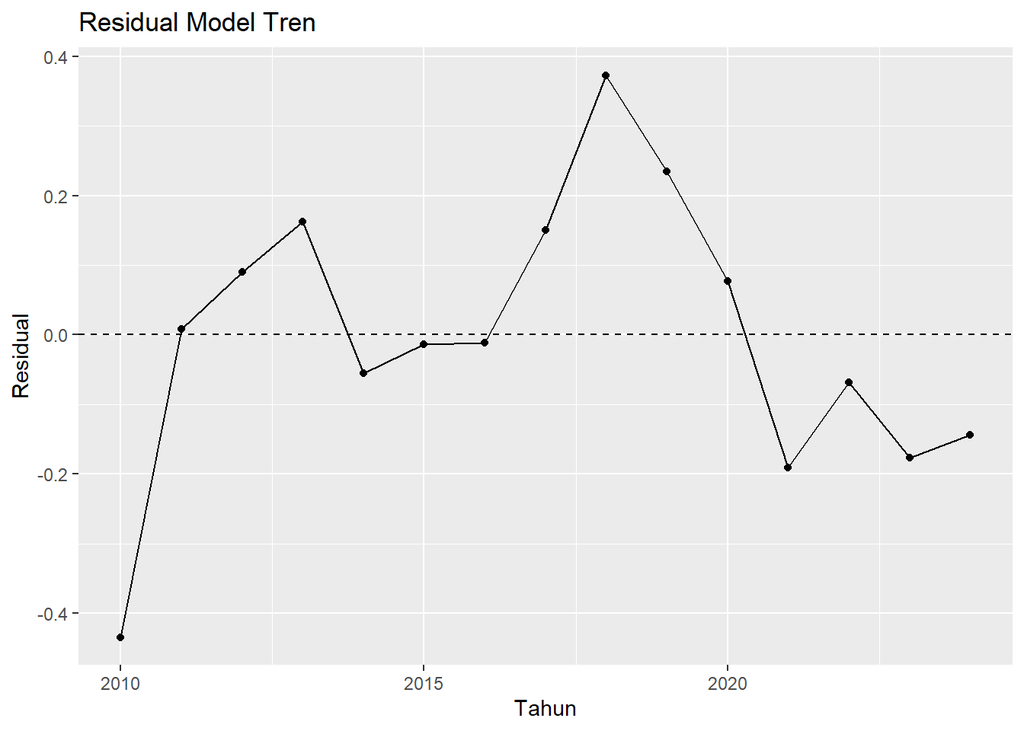

```r
dat$e_hat <- resid(mod)

ggplot(dat, aes(x = Tahun, y = e_hat)) +
  geom_hline(yintercept = 0, linetype = 2) +
  geom_line() + geom_point() +
  labs(title = "Residual Model Tren", x = "Tahun", y = "Residual")
```

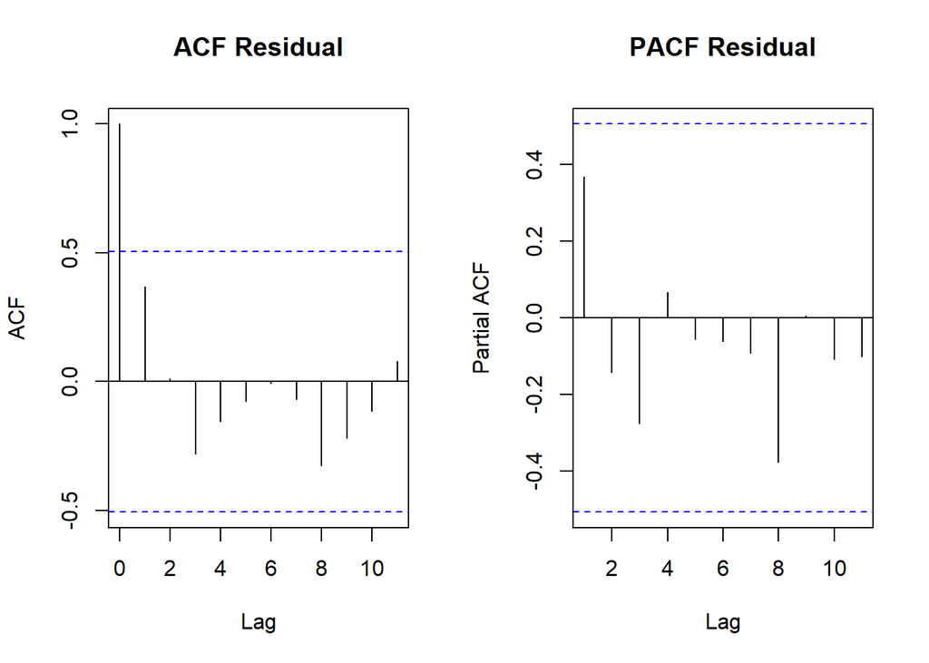

```r
par(mfrow=c(1,2))
acf(dat$e_hat, main = "ACF Residual")
pacf(dat$e_hat, main = "PACF Residual")
```

```r
par(mfrow=c(1,1))
```

Berdasarkan plot ACF dan PACF, terlihat semua dalam rentang batas dan tidak ada lag yang signifikan. Namun, untuk lebih memastikan akan dilakukan uji formal dengan uji Durbin Watson. # Periksa Autokorelasi DW-Test

```r
library(lmtest)
dwtest(mod, alternative = "two.sided")
```

```
##
##  Durbin-Watson test
##
## data:  mod
## DW = 0.87679, p-value = 0.004566
## alternative hypothesis: true autocorrelation is not 0
```

Dengan nilai p-value < 0.05 dapat disimpulkan bahwa tolak H0, cukup bukti mengatakan adanya autokorelasi. Oleh karena itu, diperlukan penangan autokorelasi.

# Cochrane-Orcutt

```r
if (!require(orcutt)) {
  install.packages("remotes", repos = "https://cloud.r-project.org")
  remotes::install_github("cran/orcutt")
  library(orcutt)
}
model <- lm(IPM ~ Tahun, data = dat)

library(orcutt)
modelCO <- cochrane.orcutt(model)
summary(modelCO)
```

```
## Call:
## lm(formula = IPM ~ Tahun, data = dat)
##
##                Estimate  Std. Error t value  Pr(>|t|)
## (Intercept) -1.1584e+03  2.9784e+01 -38.895 5.377e-14 ***
## Tahun        6.1030e-01  1.4757e-02  41.356 2.589e-14 ***
## ---
## Signif. codes:  0 '***' 0.001 '**' 0.01 '*' 0.05 '.' 0.1 ' ' 1
##
## Residual standard error: 0.1314 on 12 degrees of freedom
## Multiple R-squared:  0.993 ,  Adjusted R-squared:  0.9925
## F-statistic: 1710.3 on 1 and 12 DF,  p-value: < 2.589e-14
##
## Durbin-Watson statistic
## (original):    0.87679 , p-value: 2.283e-03
## (transformed): 1.56190 , p-value: 1.155e-01
```

Hasil juga menunjukkan bahwa nilai DW dan p-value meningkat menjadi 1.56190 dan 1.155e-01. nilai p-value > 0.05, artinya belum cukup bukti menyatakan bahwa sisaan terdapat autokorelasi pada taraf nyata 5%. Untuk nilai ρ̂ optimum yang digunakan adalah 0.409568

# Metode Cochrane-Orcutt Manual

```r
rho<- modelCO$rho
rho
```

```
## [1] 0.4095683
```

```r
IPM.trans   <- dat$IPM[-1]   - dat$IPM[-length(dat$IPM)] * rho
Tahun.trans <- dat$Tahun[-1] - dat$Tahun[-length(dat$Tahun)] * rho

modelCOmanual <- lm(IPM.trans ~ Tahun.trans)
summary(modelCOmanual)
```

```
##
## Call:
## lm(formula = IPM.trans ~ Tahun.trans)
##
## Residuals:
##       Min        1Q    Median        3Q       Max
## -0.205889 -0.057963  0.000808  0.055225  0.292434
##
## Coefficients:
##               Estimate Std. Error t value Pr(>|t|)
## (Intercept) -683.97266   17.58515  -38.90 5.38e-14 ***
## Tahun.trans    0.61031    0.01476   41.36 2.59e-14 ***
## ---
## Signif. codes:  0 '***' 0.001 '**' 0.01 '*' 0.05 '.' 0.1 ' ' 1
##
## Residual standard error: 0.1314 on 12 degrees of freedom
## Multiple R-squared:  0.993,  Adjusted R-squared:  0.9925
## F-statistic:  1710 on 1 and 12 DF,  p-value: 2.589e-14
```

```r
b0bintang <- modelCOmanual$coefficients[1]
b1        <- modelCOmanual$coefficients[2]

b0 <- b0bintang / (1 - rho)
b0
```

```
## (Intercept)
##   -1158.428
```

```r
b1
```

```
## Tahun.trans
##   0.6103053
```

Hasil perhitungan koefisien regresi tersebut akan menghasilkan hasil yang sama dengan model yang dihasilkan menggunakan packages # Metode Hidreth-Lu.

```r
model <- lm(IPM ~ Tahun, data = dat)

hildreth.lu.func <- function(r, model){
  x <- model.matrix(model)[,-1]       # variabel X (Tahun)
  y <- model.response(model.frame(model)) # variabel Y (IPM)
  n <- length(y)
  t <- 2:n

  y <- y[t] - r * y[t-1]
  x <- x[t] - r * x[t-1]

  return(lm(y ~ x))
}

r <- seq(0.1, 0.9, by = 0.1)
tab <- data.frame(
  rho = r,
  SSE = sapply(r, function(i) deviance(hildreth.lu.func(i, model)))
)
round(tab, 4)
```

```
##   rho    SSE
## 1 0.1 0.2566
## 2 0.2 0.2299
## 3 0.3 0.2134
## 4 0.4 0.2073
## 5 0.5 0.2115
## 6 0.6 0.2259
## 7 0.7 0.2507
## 8 0.8 0.2858
## 9 0.9 0.3311
```

```r
rOpt <- seq(0.2, 0.5, by = 0.001)
tabOpt <- data.frame(
  rho = rOpt,
  SSE = sapply(rOpt, function(i) deviance(hildreth.lu.func(i, model)))
)

rho_best <- tabOpt$rho[which.min(tabOpt$SSE)]
rho_best
```

```
## [1] 0.41
```

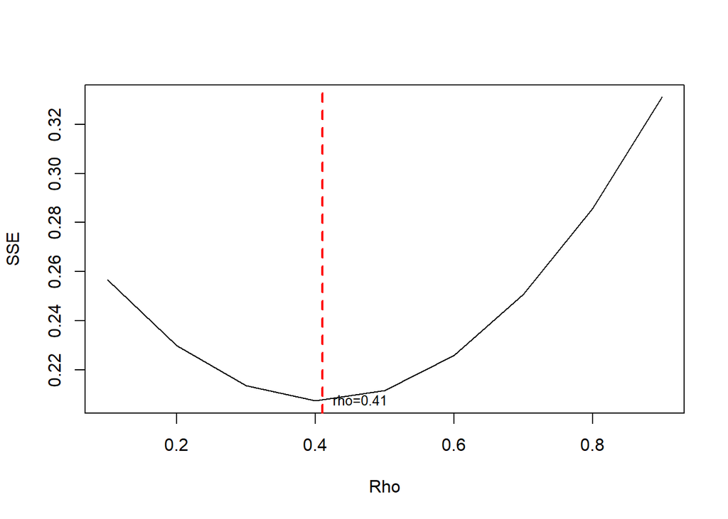

```r
plot(tab$SSE ~ tab$rho, type = "l", xlab = "Rho", ylab = "SSE")
abline(v = rho_best, lty = 2, col = "red", lwd = 2)
text(x = rho_best, y = min(tabOpt$SSE), labels = paste0("rho=", round(rho_best,3)), pos = 4, cex = 0.8)
```

```r
modelHL <- hildreth.lu.func(rho_best, model)
summary(modelHL)
```

```
##
## Call:
## lm(formula = y ~ x)
##
## Residuals:
##       Min        1Q    Median        3Q       Max
## -0.205961 -0.057944  0.000809  0.055341  0.292374
##
## Coefficients:
##               Estimate Std. Error t value Pr(>|t|)
## (Intercept) -683.44439   17.58517  -38.87 5.43e-14 ***
## x              0.61028    0.01477   41.32 2.61e-14 ***
## ---
## Signif. codes:  0 '***' 0.001 '**' 0.01 '*' 0.05 '.' 0.1 ' ' 1
##
## Residual standard error: 0.1314 on 12 degrees of freedom
## Multiple R-squared:  0.993,  Adjusted R-squared:  0.9924
## F-statistic:  1708 on 1 and 12 DF,  p-value: 2.613e-14
```

```r
cat("y = ",
    round(coef(modelHL)[1] / (1 - rho_best), 4),
    "+",
    round(coef(modelHL)[2], 4),
    "* x\n")
```

```
## y =  -1158.38 + 0.6103 * x
```

```r
library(lmtest)
dwtest(modelHL)
```

```
##
##  Durbin-Watson test
##
## data:  modelHL
## DW = 1.5625, p-value = 0.1158
## alternative hypothesis: true autocorrelation is greater than 0
```

```r
sseModelawal <- anova(model)$`Sum Sq`[-1]
sseModelCO   <- anova(modelCOmanual)$`Sum Sq`[-1]  # dari Cochrane-Orcutt
sseModelHL   <- anova(modelHL)$`Sum Sq`[-1]

n <- nrow(dat)
mseModelawal <- sseModelawal / n
mseModelCO   <- sseModelCO / n
mseModelHL   <- sseModelHL / n
```

p-value sebesar 0.1158, di mana p-value > α=5%. Artinya tak tolak H0 atau belum cukup bukti menyatakan bahwa ada autokorelasi dalam data nilai IPM dengan metode Hildreth-Lu pada taraf nyata 5%.

# Matriks perbandingan

```r
akurasi <- matrix(c(sseModelawal, sseModelCO, sseModelHL,
                    mseModelawal, mseModelCO, mseModelHL),
                  nrow = 2, ncol = 3, byrow = TRUE)
colnames(akurasi) <- c("Model Awal", "Cochrane-Orcutt", "Hildreth-Lu")
rownames(akurasi) <- c("SSE", "MSE")
akurasi
```

```
##     Model Awal Cochrane-Orcutt Hildreth-Lu
## SSE 0.54240762      0.20726572  0.20726581
## MSE 0.03616051      0.01381771  0.01381772
```

Berdasarkan hasil tersebut dapat diketahui bahwa hasil penanganan autokorelasi dengan metode Cochrane-Orcutt dan Hildreth-Lu memiliki SSE yang hampir sama, sebesar 0.20726572 dan 0.20726581 dan lebih baik dibandingkan model awal ketika autokorelasi masih terjadi, yaitu sebesar 0.54240762 .